# Homework 2

Steph Jordan

Loading necessary libraries

```r
library(dplyr)
```

```r
library(ggplot2)
library(readr)
```

Bringing in NC birth data

```r
nc <- read_csv("https://docs.google.com/spreadsheets/d/e/2PACX-1vTm2WZwNBoQdZhMgot7urbtu8eG7tzAq-60ZJsQ_nupykCAcW0OXebVpHksPWyR4x8xJTVQ8KAulAFS/pub?gid=202410847&single=true&output=csv")
```

Checking out (‘glimpsing’) nc data set

```r
glimpse(nc)
```

```
## Rows: 800
## Columns: 13
## $ fage           <dbl> 19, 21, 18, 17, 20, 30, 21, 14, 16, 20, 18, 20, 20, 26,…
## $ mage           <dbl> 15, 15, 15, 15, 16, 16, 16, 16, 16, 17, 17, 17, 17, 17,…
## $ mature         <chr> "younger mom", "younger mom", "younger mom", "younger m…
## $ weeks          <dbl> 37, 41, 37, 35, 37, 45, 38, 40, 24, 40, 37, 40, 39, 38,…
## $ premie         <chr> "full term", "full term", "full term", "premie", "full …
## $ visits         <dbl> 11, 6, 12, 5, 13, 9, 15, 12, 5, 8, 10, 17, 9, 11, 10, 1…
## $ marital        <chr> "married", "married", "married", "married", "married", …
## $ gained         <dbl> 38, 34, 76, 15, 52, 28, 75, 9, 12, 20, 39, 38, 36, 30, …
## $ weight         <dbl> 6.63, 8.00, 8.44, 4.69, 6.94, 7.44, 7.56, 5.81, 1.50, 8…
## $ lowbirthweight <chr> "not low", "not low", "not low", "low", "not low", "not…
## $ gender         <chr> "female", "male", "male", "male", "female", "male", "fe…
## $ habit          <chr> "nonsmoker", "nonsmoker", "nonsmoker", "nonsmoker", "no…
## $ whitemom       <chr> "white", "white", "not white", "not white", "white", "w…
```

## Excercise 1

Habit is a character. Visits is a double (a decimal number).

## Scatterplots

Making a scatterplot of weeks and weight

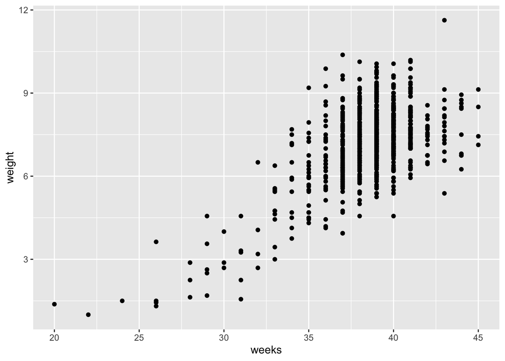

```r
ggplot(data = nc, aes(x = weeks, y = weight)) +
  geom_point()
```

Adding labels to our scatterplot

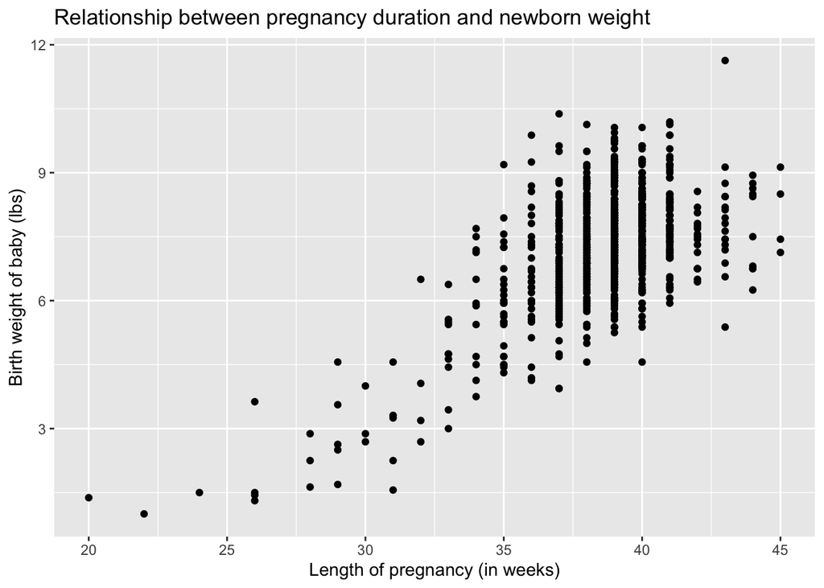

```r
ggplot(data = nc, aes(x = weeks, y = weight)) +
  geom_point() +
  labs(x = "Length of pregnancy (in weeks)", y = "Birth weight of baby (lbs)",
       title = "Relationship between pregnancy duration and newborn weight")
```

## Excercise 2

There is a positive relationship between these 2 variables, which means as the length of pregnancy increases, the birth weight of the baby also increases.

## Excercise 3

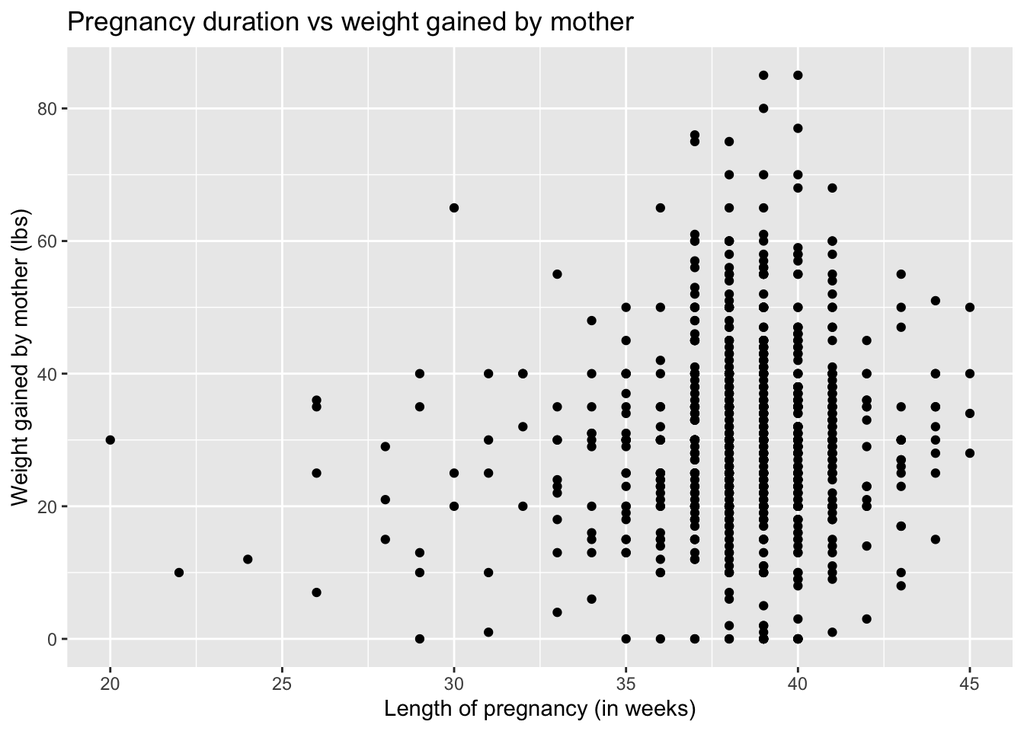

```r
ggplot(data = nc, aes(x = weeks, y = gained)) +
  geom_point() +
  labs(x = "Length of pregnancy (in weeks)", y = "Weight gained by mother (lbs)",
       title = "Pregnancy duration vs weight gained by mother")
```

## Excercise 5

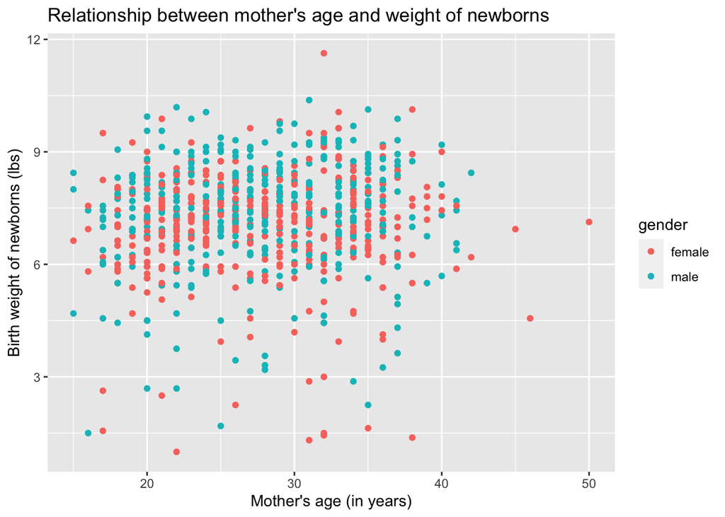

```r
ggplot(data = nc, aes(x = mage, y = weight, color = gender)) +
  geom_point() +
  labs(x = "Mother's age (in years)", y = "Birth weight of newborns (lbs)",
       title = "Relationship between mother's age and weight of newborns")
```

There doesn’t appear to be a strong relationship between mother’s age and birth weight of newborns. This is evident from the lack of upward trending (towards the ‘northeast’ quadrant) and lack of downward trending (towards the ‘southeast’ quadrant) in the data.

## Histograms

Histogram (counts) of weeks

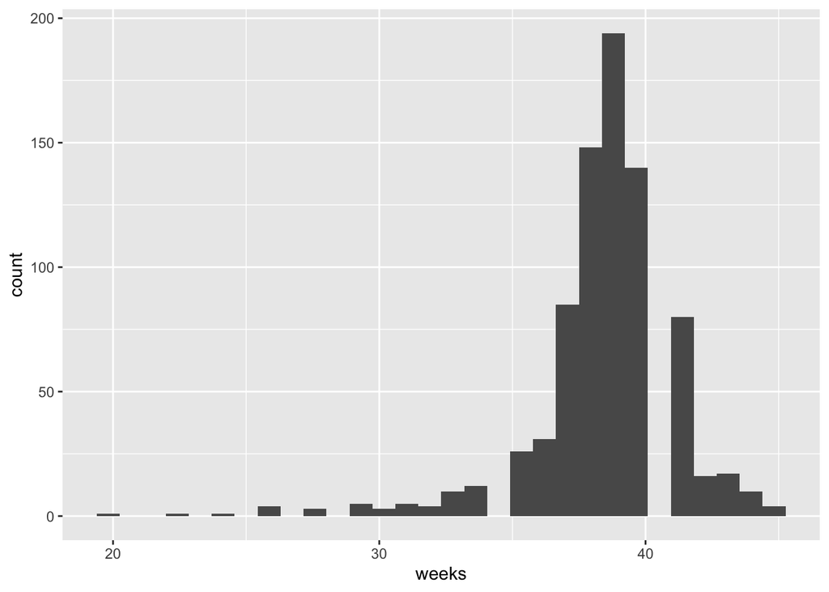

```r
ggplot(data = nc, aes(x = weeks))+
  geom_histogram()
```

Changing colors and binwidth

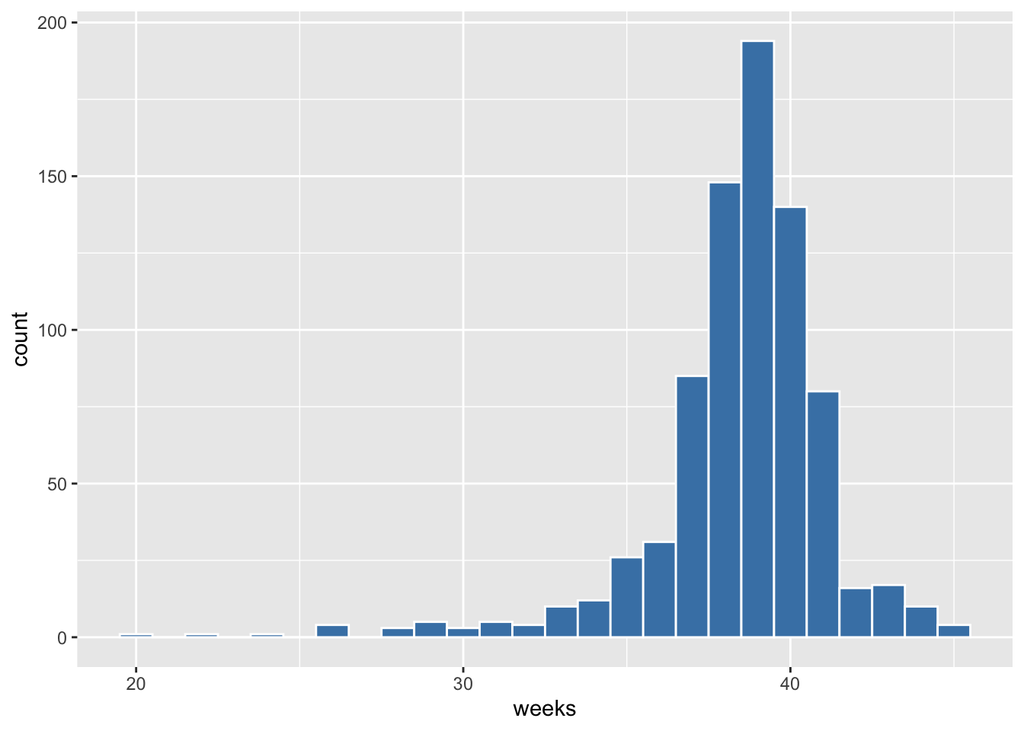

```r
ggplot(data = nc, aes(x = weeks))+
  geom_histogram(binwidth = 1, color = "white", fill = "steelblue")
```

## Excercise 7

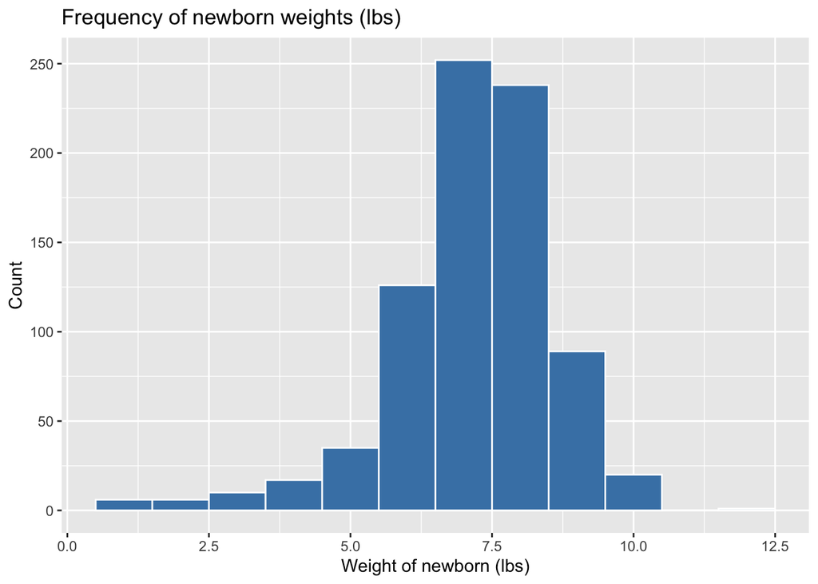

```r
ggplot(data = nc, aes(x = weight))+
  geom_histogram(binwidth = 1, color = "white", fill = "steelblue") +
  labs(x = "Weight of newborn (lbs)", y = "Count",
       title = "Frequency of newborn weights (lbs)")
```

## Faceting

Here, we differentiate between cases with mother status “young” and mother status “mature” by using faceting. These two histograms will share the same categorical variable, but will be split into two plots based on the value cases possess for the ‘mature’ variable.

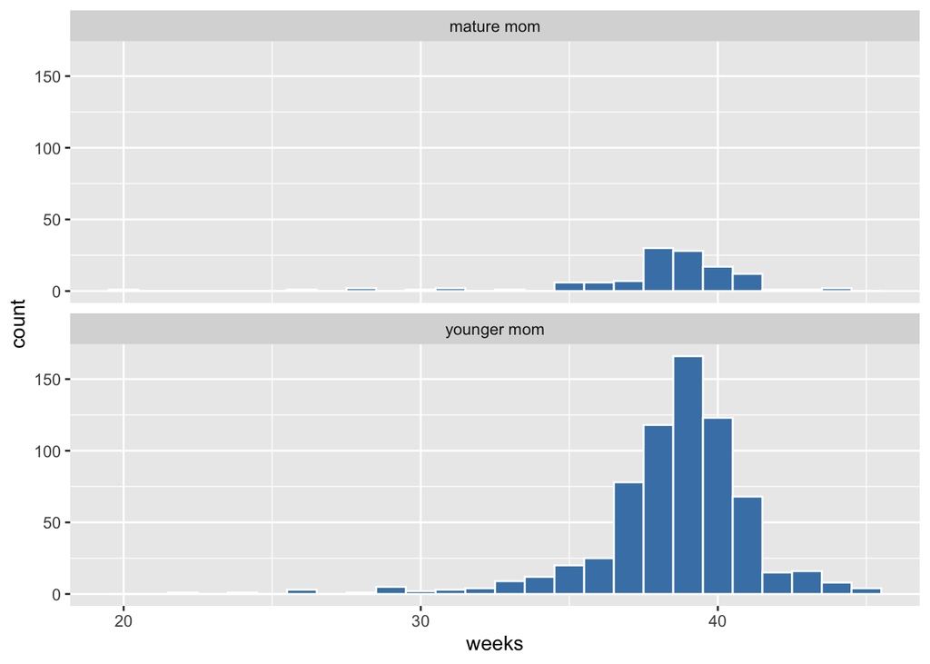

```r
ggplot(data = nc, aes(x = weeks)) +
  geom_histogram(binwidth = 1, color = "white", fill = "steelblue") +
  facet_wrap(~ mature, ncol = 1)
```

## Excercise 8

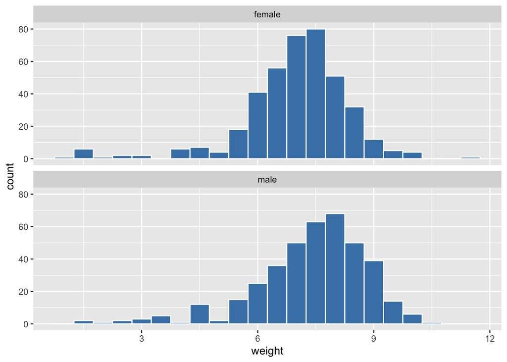

```r
ggplot(data = nc, aes(x = weight)) +
  geom_histogram(binwidth = 0.5, color = "white", fill = "steelblue") +
  facet_wrap(~ gender, ncol = 1)
```

Male babies tend to have a slightly higher average weight. This is evident because there is similar symmetry in the male and female histograms, but the center of the male histogram (the peak bin) is slightly higher.

## Boxplots

Boxplot of weight gained by mothers with male vs female babies. The length of the box is called the interquartile range (IQR)–it represents the middle 50% of the data set. Bottom half of box is 25 percentile to 50th percentile (the median). Top of box is 75th percentile, so from the middle to top of box is 50th percentile to 75th percentile. Lines beyond and below the box represent values above 75th percentile and below 25th percentile, respectively. These whiskers never extend more than 1.5 IQRs from the box ends. The dots are outliers.

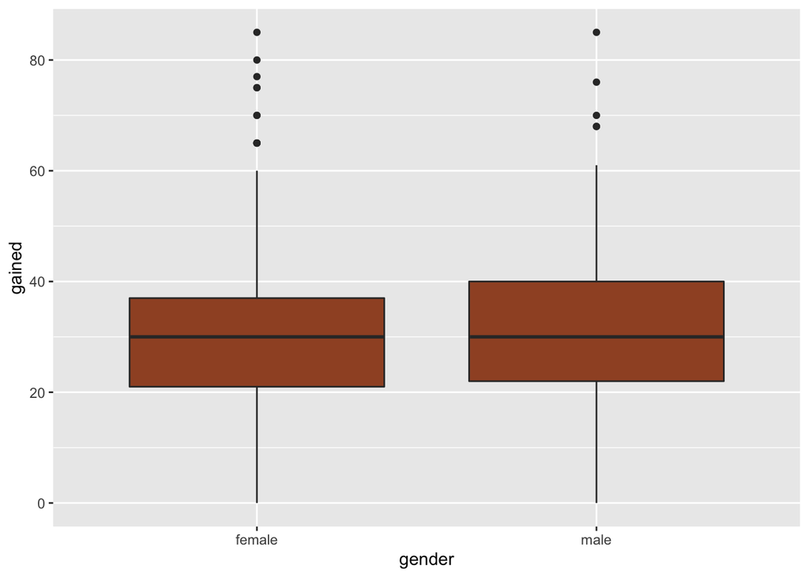

```r
ggplot(data = nc, aes(x = gender, y = gained)) +
  geom_boxplot(fill = "sienna")
```

## Excercise 9

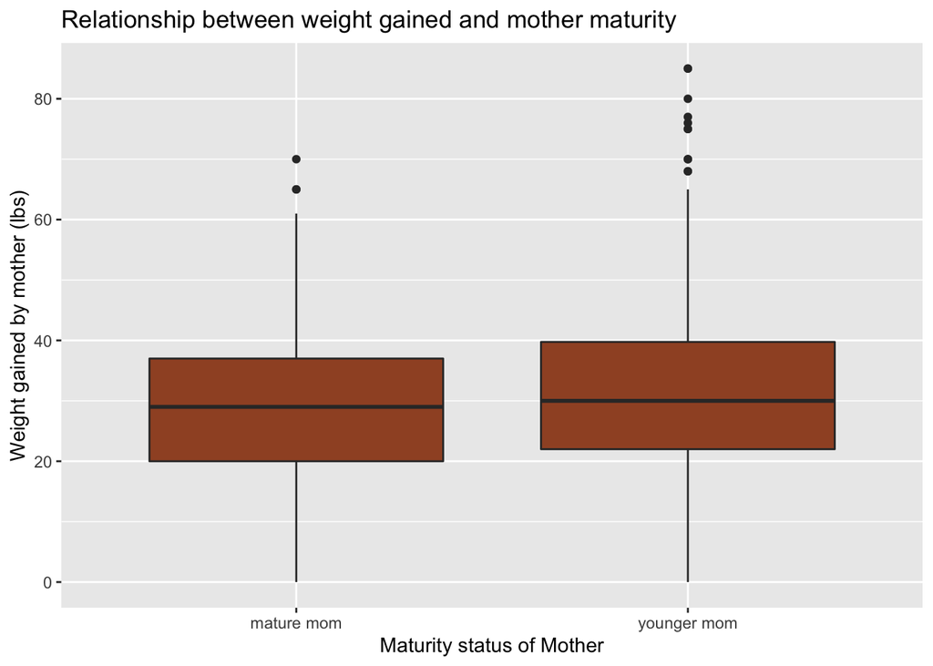

```r
ggplot(data = nc, aes(x = mature, y = gained)) +
  geom_boxplot(fill = "sienna") +
  labs(x = "Maturity status of Mother", y = "Weight gained by mother (lbs)",
       title = "Relationship between weight gained and mother maturity")
```

The median weight gained for Young moms is higher. This is evident because the middle line in the young mom’s boxplot is higher than that for mature mom’s.

## Excercise 10

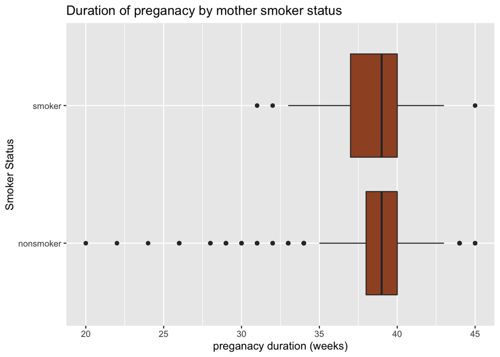

```r
ggplot(data = nc, aes(x = weeks, y = habit)) +
  geom_boxplot(fill = "sienna") +
  labs(x = "preganacy duration (weeks)", y = "Smoker Status",
       title = "Duration of preganacy by mother smoker status")
```

Smoker mothers have more variability in length of pregnancy, since the whiskers for their plot are longer.

## Excercise 11

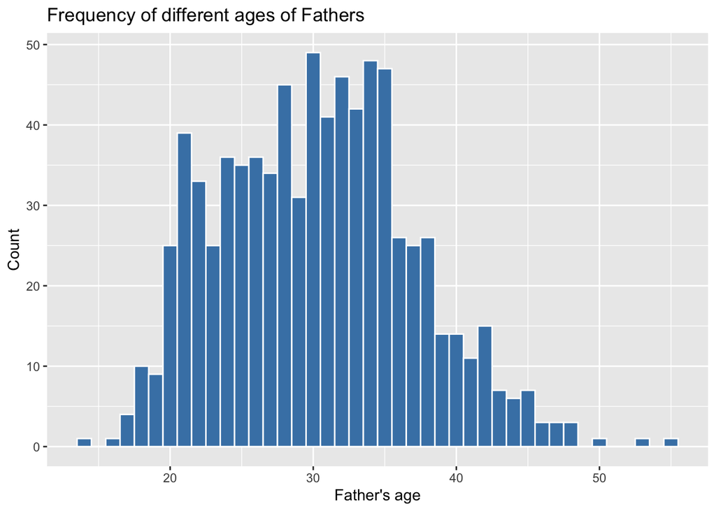

```r
ggplot(data = nc, aes(x = fage))+
  geom_histogram(binwidth = 1, color = "white", fill = "steelblue") +
  labs(x = "Father's age", y = "Count",
       title = "Frequency of different ages of Fathers")
```

Father’s age is mostly symmetrical, with a slight rightward skew.

## Excercise 12

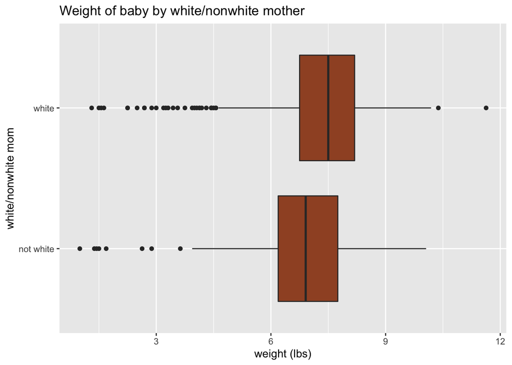

```r
ggplot(data = nc, aes(x = weight, y = whitemom)) +
  geom_boxplot(fill = "sienna") +
  labs(x = "weight (lbs)", y = "white/nonwhite mom",
       title = "Weight of baby by white/nonwhite mother")
```

The median birth weight for babies with white moms is higher. This is evident because the middle line in the white mom’s boxplot is higher than that for nonwhite mom’s.

## Excercise 13

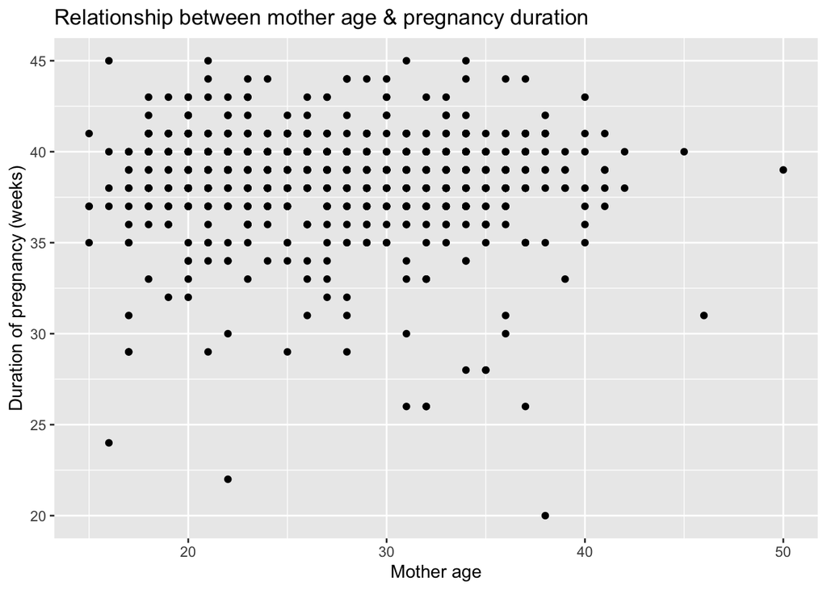

```r
ggplot(data = nc, aes(x = mage, y = weeks)) +
  geom_point() +
  labs(x = "Mother age", y = "Duration of pregnancy (weeks)",
       title = "Relationship between mother age & pregnancy duration")
```

No, there is not a strong negative correlation between mother’s age and the duration of pregnancy. This is evident because there is no strong trending (towards the ‘northeast’ or ‘southeast’ corner of the graph, which would indicate a positive or negative correlation, respectively).